# R Notebook

Required packages

```r
library("geosphere")
library("ggplot2")
library("ggmap")
library("tidyr")
library("ggplot2")
library('MASS')
```

This data has been modified to include the distance from Sydney for each SA2 region. Distance is calculated using geosphere which implements the haversine function. The accuracy is not necessarily precise giving the nature of the calculations. Distance may not be measured from the center of each SA2 region.

```r
# Population estimates by SA2 and above (ASGS2021), 2001 to 2021
df = read.csv("C:\\Users/Laura/OneDrive - Western Sydney University\\Spring 2022\\Mathematics Project\\Data Sets Modified\\Population_done.csv")
```

Check that the data has loaded in correctly

```r
head(df,5)
```

|  | X | SA2_Code | SA2_Name | X2001 | X2002 | X2003 | X2004 | X2005 | X2006 | X2007 | X2008 | X2009 | X2010 | X2011 | X2012 | X2013 | X2014 | X2015 | X2016 | X2017 | X2018 | X2019 | X2020 | X2021 | Change_No. | Change_Percentage. | Area_Km2. | Population_Density | distance_from_syd |
| --- | --- | --- | --- | --- | --- | --- | --- | --- | --- | --- | --- | --- | --- | --- | --- | --- | --- | --- | --- | --- | --- | --- | --- | --- | --- | --- | --- | --- | --- |
| 1 | 1 | 101021007 | Braidwood | 2760 | 2811 | 2835 | 2844 | 2847 | 2965 | 3102 | 3181 | 3308 | 3429 | 3458 | 3590 | 3685 | 3762 | 3849 | 3950 | 4039 | 4140 | 4211 | 4273 | 4330 | 872 | 25.2 | 3418.4 | 1.3 | 217.9416 |
| 2 | 2 | 101021008 | Karabar | 9129 | 9199 | 9263 | 9277 | 9209 | 9212 | 9033 | 8994 | 9030 | 9101 | 9092 | 9012 | 8848 | 8731 | 8603 | 8531 | 8526 | 8507 | 8488 | 8519 | 8546 | -546 | -6.0 | 7.0 | 1223.9 | 246.8096 |
| 3 | 3 | 101021009 | Queanbeyan | 9717 | 9513 | 9522 | 9400 | 9595 | 9682 | 9793 | 10074 | 10288 | 10584 | 10715 | 10870 | 11050 | 11199 | 11213 | 11230 | 11355 | 11447 | 11450 | 11437 | 11370 | 655 | 6.1 | 4.8 | 2387.7 | 244.9884 |
| 4 | 4 | 101021010 | Queanbeyan - East | 3925 | 4073 | 4219 | 4218 | 4187 | 4319 | 4459 | 4595 | 4712 | 4813 | 4951 | 4971 | 4983 | 4967 | 4961 | 4970 | 5013 | 5072 | 5117 | 5077 | 5093 | 142 | 2.9 | 13.0 | 391.7 | 243.9411 |
| 5 | 5 | 101021012 | Queanbeyan West - Jerrabomberra | 9425 | 10257 | 11085 | 11549 | 12046 | 12358 | 12622 | 12798 | 12988 | 13146 | 13223 | 13204 | 13210 | 13193 | 13164 | 13150 | 13083 | 13008 | 12935 | 12796 | 12743 | -480 | -3.6 | 13.7 | 931.9 | 246.6952 |

For loop to correct the year column names. Want them to be numeric and not include ‘X’

```r
for (x in 4:24){
  name = 1997 + x
  colnames(df)[x] <- name
}
```

Fixed

```r
head(df,5)
```

|  | X | SA2_Code | SA2_Name | 2001 | 2002 | 2003 | 2004 | 2005 | 2006 | 2007 | 2008 | 2009 | 2010 | 2011 | 2012 | 2013 | 2014 | 2015 | 2016 | 2017 | 2018 | 2019 | 2020 | 2021 | Change_No. | Change_Percentage. | Area_Km2. | Population_Density | distance_from_syd |
| --- | --- | --- | --- | --- | --- | --- | --- | --- | --- | --- | --- | --- | --- | --- | --- | --- | --- | --- | --- | --- | --- | --- | --- | --- | --- | --- | --- | --- | --- |
| 1 | 1 | 101021007 | Braidwood | 2760 | 2811 | 2835 | 2844 | 2847 | 2965 | 3102 | 3181 | 3308 | 3429 | 3458 | 3590 | 3685 | 3762 | 3849 | 3950 | 4039 | 4140 | 4211 | 4273 | 4330 | 872 | 25.2 | 3418.4 | 1.3 | 217.9416 |
| 2 | 2 | 101021008 | Karabar | 9129 | 9199 | 9263 | 9277 | 9209 | 9212 | 9033 | 8994 | 9030 | 9101 | 9092 | 9012 | 8848 | 8731 | 8603 | 8531 | 8526 | 8507 | 8488 | 8519 | 8546 | -546 | -6.0 | 7.0 | 1223.9 | 246.8096 |
| 3 | 3 | 101021009 | Queanbeyan | 9717 | 9513 | 9522 | 9400 | 9595 | 9682 | 9793 | 10074 | 10288 | 10584 | 10715 | 10870 | 11050 | 11199 | 11213 | 11230 | 11355 | 11447 | 11450 | 11437 | 11370 | 655 | 6.1 | 4.8 | 2387.7 | 244.9884 |
| 4 | 4 | 101021010 | Queanbeyan - East | 3925 | 4073 | 4219 | 4218 | 4187 | 4319 | 4459 | 4595 | 4712 | 4813 | 4951 | 4971 | 4983 | 4967 | 4961 | 4970 | 5013 | 5072 | 5117 | 5077 | 5093 | 142 | 2.9 | 13.0 | 391.7 | 243.9411 |
| 5 | 5 | 101021012 | Queanbeyan West - Jerrabomberra | 9425 | 10257 | 11085 | 11549 | 12046 | 12358 | 12622 | 12798 | 12988 | 13146 | 13223 | 13204 | 13210 | 13193 | 13164 | 13150 | 13083 | 13008 | 12935 | 12796 | 12743 | -480 | -3.6 | 13.7 | 931.9 | 246.6952 |

I’m not sure if there’s a cleaner way to do this given the number of variables but here’s the data in long formaat.

```r
df = df %>% pivot_longer(cols=c('2001', '2002', '2003', '2004', '2005', '2006', '2007', '2008', '2009', '2010',  '2011', '2012', '2013', '2014', '2015', '2016', '2017', '2018', '2019', '2020', '2021'),
                    names_to='year',
                    values_to='Pop')
```

```r
head(df,5)
```

| X | SA2_Code | SA2_Name | Change_No. | Change_Percentage. | Area_Km2. | Population_Density | distance_from_syd | year | Pop |
| --- | --- | --- | --- | --- | --- | --- | --- | --- | --- |
| 1 | 101021007 | Braidwood | 872 | 25.2 | 3418.4 | 1.3 | 217.9416 | 2001 | 2760 |
| 1 | 101021007 | Braidwood | 872 | 25.2 | 3418.4 | 1.3 | 217.9416 | 2002 | 2811 |
| 1 | 101021007 | Braidwood | 872 | 25.2 | 3418.4 | 1.3 | 217.9416 | 2003 | 2835 |
| 1 | 101021007 | Braidwood | 872 | 25.2 | 3418.4 | 1.3 | 217.9416 | 2004 | 2844 |
| 1 | 101021007 | Braidwood | 872 | 25.2 | 3418.4 | 1.3 | 217.9416 | 2005 | 2847 |

```r
dim(df)
```

```
[1] 13503    10
```

Add new column for population density. Current one only accounts for 2021 Assigning the value to the new column values. Can’t assign double values otherwise sine the column because type logical

```r
df['density_2'] <- 0.0
```

```r
head(df,4)
```

| X | SA2_Code | SA2_Name | Change_No. | Change_Percentage. | Area_Km2. | Population_Density | distance_from_syd | year | Pop | density_2 |
| --- | --- | --- | --- | --- | --- | --- | --- | --- | --- | --- |
| 1 | 101021007 | Braidwood | 872 | 25.2 | 3418.4 | 1.3 | 217.9416 | 2001 | 2760 | 0 |
| 1 | 101021007 | Braidwood | 872 | 25.2 | 3418.4 | 1.3 | 217.9416 | 2002 | 2811 | 0 |
| 1 | 101021007 | Braidwood | 872 | 25.2 | 3418.4 | 1.3 | 217.9416 | 2003 | 2835 | 0 |
| 1 | 101021007 | Braidwood | 872 | 25.2 | 3418.4 | 1.3 | 217.9416 | 2004 | 2844 | 0 |

Calculate population density for each region for each year.

```r
for(x in 1:13503){
  pop_x = df[x,10]
  area_x = df[x,6]
  density_x = (pop_x/area_x)
  df[x,11] = density_x
}
```

```r
dim(df)
```

```
[1] 13503    11
```

```r
new_df = df[!grepl(0, df$Pop),]
dim(new_df)
```

```
[1] 9020   11
```

From the plot the data resembles a negative exponential function. It doesn’t look positive or negatively linear.

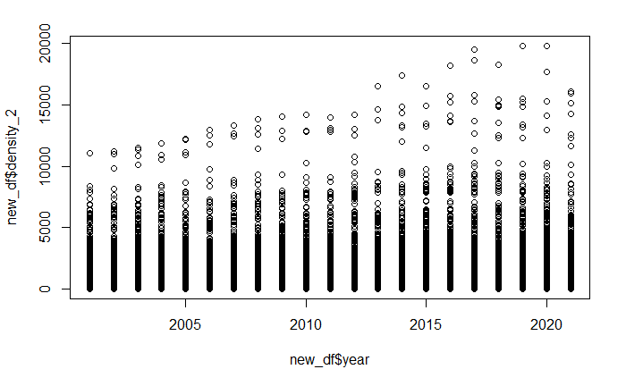

```r
plot(new_df$density_2 ~ new_df$year*(new_df$distance_from_syd))
```

[figure not shown]

```r
NA
```

Rough guestimate of what the function looks like. Obviously most of our samples happen close to Sydney. City’s tend to be more densely populated.

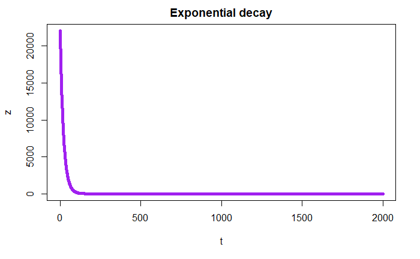

```r
t=0:2000
z= 33 + exp(10-(t/21))
plot(t,z, type="l", col="purple", lwd=5, main="Exponential decay")
```

Lets try a negative exponential model Not quite sure this is the right way to run the model.

```r
model_e = glm(density_2 ~ as.integer(year)*(distance_from_syd), data = new_df)
summary(model_e)
```

```
Call:
glm(formula = density_2 ~ as.integer(year) * (distance_from_syd),
    data = new_df)

Deviance Residuals:
    Min       1Q   Median       3Q      Max
-2884.8  -1353.1   -417.4    778.7  16953.8

Coefficients:
                                     Estimate Std. Error t value Pr(>|t|)
(Intercept)                        -8.295e+04  9.006e+03  -9.210  < 2e-16 ***
as.integer(year)                    4.251e+01  4.478e+00   9.491  < 2e-16 ***
distance_from_syd                   2.046e+02  3.958e+01   5.170 2.40e-07 ***
as.integer(year):distance_from_syd -1.047e-01  1.968e-02  -5.320 1.06e-07 ***
---
Signif. codes:  0 ‘***’ 0.001 ‘**’ 0.01 ‘*’ 0.05 ‘.’ 0.1 ‘ ’ 1

(Dispersion parameter for gaussian family taken to be 4156353)

    Null deviance: 4.8049e+10  on 9019  degrees of freedom
Residual deviance: 3.7474e+10  on 9016  degrees of freedom
AIC: 163070

Number of Fisher Scoring iterations: 2
```

Plot the model

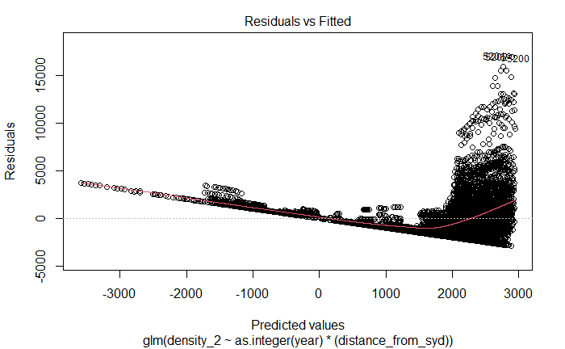

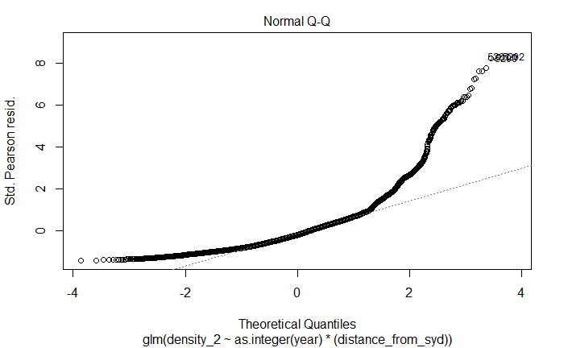

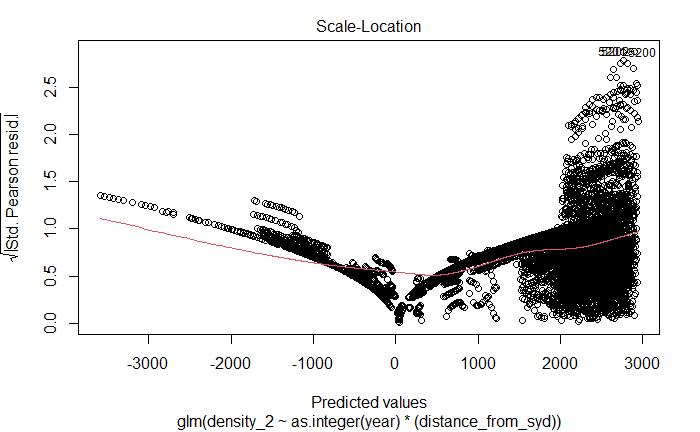

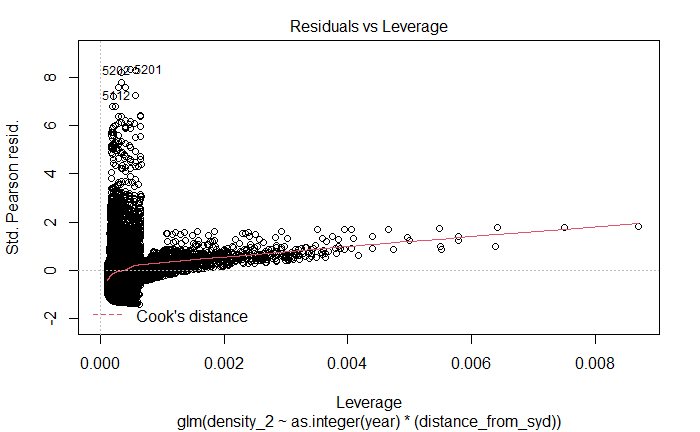

```r
plot(model_e)
```

```r
model_density = lm(density_2~as.integer(year)*(distance_from_syd) + (year=='2020')*(distance_from_syd), data = new_df)
summary(model_density)
```

```
Call:
lm(formula = density_2 ~ as.integer(year) * (distance_from_syd) +
    (year == "2020") * (distance_from_syd), data = new_df)

Residuals:
    Min      1Q  Median      3Q     Max
-2895.4 -1351.5  -418.9   776.1 16983.1

Coefficients:
                                       Estimate Std. Error t value Pr(>|t|)
(Intercept)                          -8.451e+04  9.563e+03  -8.837  < 2e-16 ***
as.integer(year)                      4.328e+01  4.757e+00   9.099  < 2e-16 ***
distance_from_syd                     2.099e+02  4.195e+01   5.003 5.75e-07 ***
year == "2020"TRUE                   -6.480e+01  1.336e+02  -0.485    0.628
as.integer(year):distance_from_syd   -1.073e-01  2.087e-02  -5.144 2.75e-07 ***
distance_from_syd:year == "2020"TRUE  2.228e-01  6.026e-01   0.370    0.712
---
Signif. codes:  0 ‘***’ 0.001 ‘**’ 0.01 ‘*’ 0.05 ‘.’ 0.1 ‘ ’ 1

Residual standard error: 2039 on 9014 degrees of freedom
Multiple R-squared:  0.2201,    Adjusted R-squared:  0.2197
F-statistic: 508.8 on 5 and 9014 DF,  p-value: < 2.2e-16
```

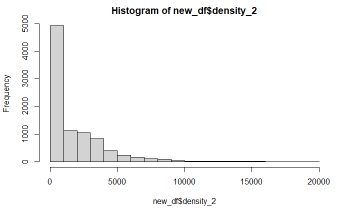

```r
hist(new_df$density_2)
```

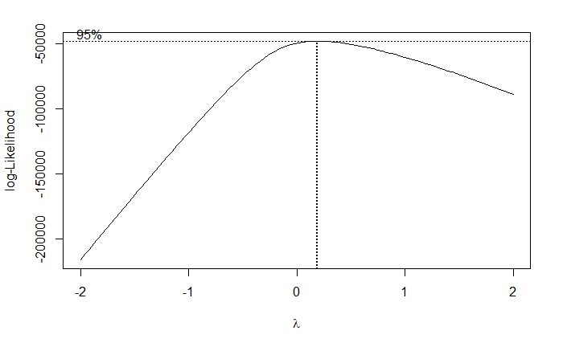

```r
y = new_df$density_2
x = as.integer(new_df$year)*(new_df$distance_from_syd)


bc <- boxcox(y ~ x)
```

```r
(lambda <- bc$x[which.max(bc$y)])
```

```
[1] 0.1818182
```

```r
lambda = 0.1818182
new_model <- lm(((y^lambda-1)/lambda) ~ x)
```

```r
summary(new_model)
```

```
Call:
lm(formula = ((y^lambda - 1)/lambda) ~ x)

Residuals:
    Min      1Q  Median      3Q     Max
-16.784  -3.739   1.152   4.074  17.342

Coefficients:
              Estimate Std. Error t value Pr(>|t|)
(Intercept)  1.490e+01  7.683e-02  193.96   <2e-16 ***
x           -1.216e-05  1.680e-07  -72.43   <2e-16 ***
---
Signif. codes:  0 ‘***’ 0.001 ‘**’ 0.01 ‘*’ 0.05 ‘.’ 0.1 ‘ ’ 1

Residual standard error: 5.728 on 9018 degrees of freedom
Multiple R-squared:  0.3678,    Adjusted R-squared:  0.3677
F-statistic:  5246 on 1 and 9018 DF,  p-value: < 2.2e-16
```

[output not shown]

```r
df[is.na(log(df$density_2)),]
```

```r
dens_omit= log(df$density_2)
sort(dens_omit)[1:5]
df[dens_omit==-Inf,]
```

[output not shown]

```r
norm_model = lm(log(density_2)~(as.integer(year))*(log(distance_from_syd)), data=new_df)
```

```r
summary(norm_model)
```

[output not shown]

```r
plot(norm_model)
```

[output not shown]

Interpretation of plots: 1. Residuals vs Fitted

2.Normal Q-Q (Shows if the residuals are normally distributed)

3. Scaled-Location Shows if residuals are spread equally along the ranges of predictors
4. Residuals vs Leverage

Does the density variable need to normalised aswell?

```r
plot(log(new_df$density_2)~as.integer(new_df$year)*(log(new_df$distance_from_syd)))
```

Links: Cox-box https://www.statology.org/box-cox-transformation-in-r/

Model Plots https://data.library.virginia.edu/diagnostic-plots/